# Project2 Phase 2

## Models And Visualization

### Start Hour - End Hour

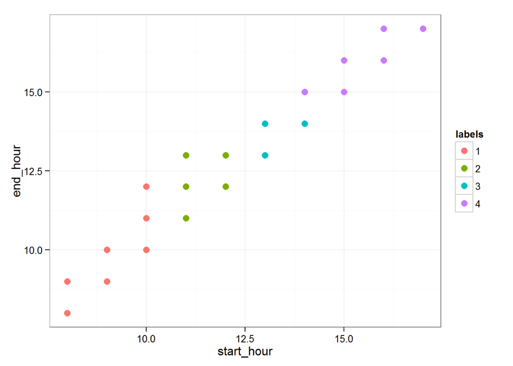

```r
library(ape)
library(RColorBrewer)
cols <- brewer.pal(3,"Set1")

# start hour - end hour
hc <- agnes(start_hour__end_hour, method="ward")
finalData$labels = factor(cutree(hc, k=4))
ggplot(finalData, aes(start_hour, end_hour)) +
  geom_point(aes(color=labels), size=3) +
  theme_bw()
```

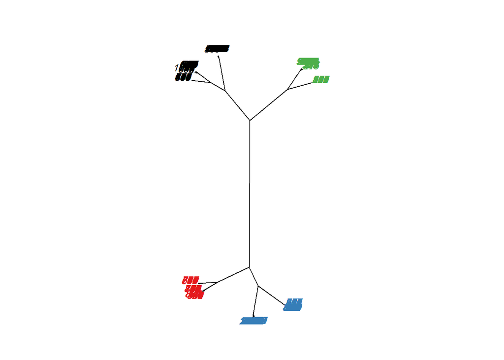

```r
hc <- as.phylo(as.hclust(agnes(start_hour__end_hour, method="ward")))
par(mar=c(1,1,2,1), xpd=NA)
plot(as.phylo(hc), type = "unrooted", cex = 0.8,
     tip.color = cols[finalData$labels])
```

```r
rm(start_hour__end_hour)
```

Visitors can be grouped by the hour they started using stations and the hour they ended using stations. It can be seen that we can segment visitors in four different clusters according to those two features. It can be concluded that visitors tend to start and end using stations in the same hour.

Sizes: First cluster - 14.3 % Second cluster - 35.5 % Third cluster - 22.4 % Fourth cluster - 27.8 %

First cluster is concentrated around 9:00 and is the smallest one. Second is concentrated around 11:00, third is concentrated around 13:00 and fourth around 16:00. 90.21 % of people from first cluster will start and end using machine in the same hour, 97.18 % of people from the second cluster will do the same thing, 98.66 % is for the third and 95.32 % is for the fourth cluster.

### Start Hour - Weekday

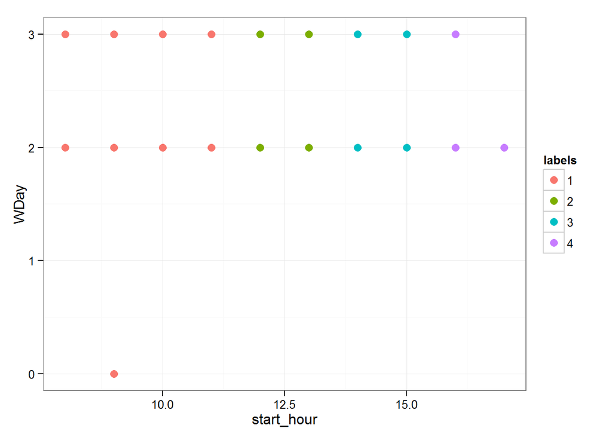

```r
hc <- agnes(start_hour__wday, method="ward")
finalData$labels = factor(cutree(hc, k=4))
ggplot(finalData, aes(start_hour, WDay)) +
  geom_point(aes(color=labels), size=3) +
  theme_bw()
```

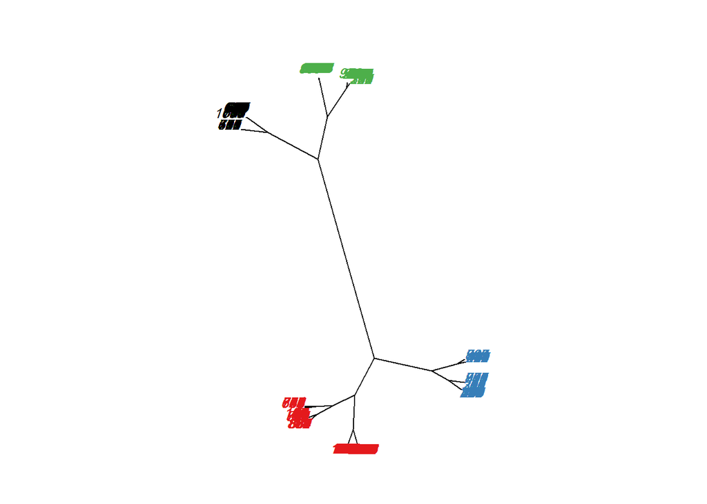

```r
hc <- as.phylo(as.hclust(agnes(start_hour__wday, method="ward")))
par(mar=c(1,1,2,1), xpd=NA)
plot(as.phylo(hc), type = "unrooted", cex = 0.8,
     tip.color = cols[finalData$labels])
```

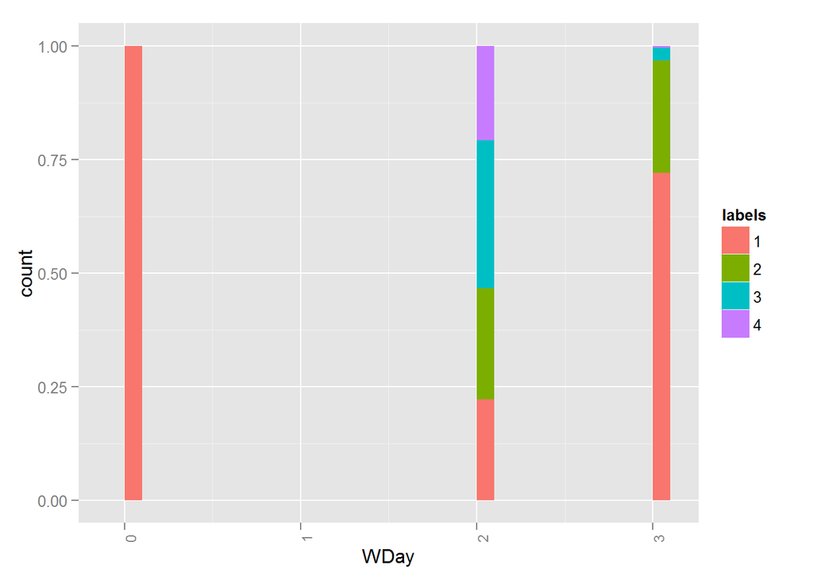

```r
ggplot(data=finalData,aes(x=WDay, fill=labels))+
  geom_bar(position = "fill")+theme(axis.text.x=element_text(angle=90,size=9))
```

```r
rm(start_hour__wday)
```

Sizes: First cluster - 34.3 % Second cluster - 24.5 % Third cluster - 25.4 % Fourth cluster - 15.8 %

First cluster is concentrated around 10:00. Second is concentrated around 12:00, third is concentrated around 14:00 and fourth around 16:00. 48.69% of people from the first cluster will use station on weekday 2, 75.51% from the second cluster will do the same, 97.24% is for the third and 99.37 is for the fourth.

### Start Hour - Time of Consuming

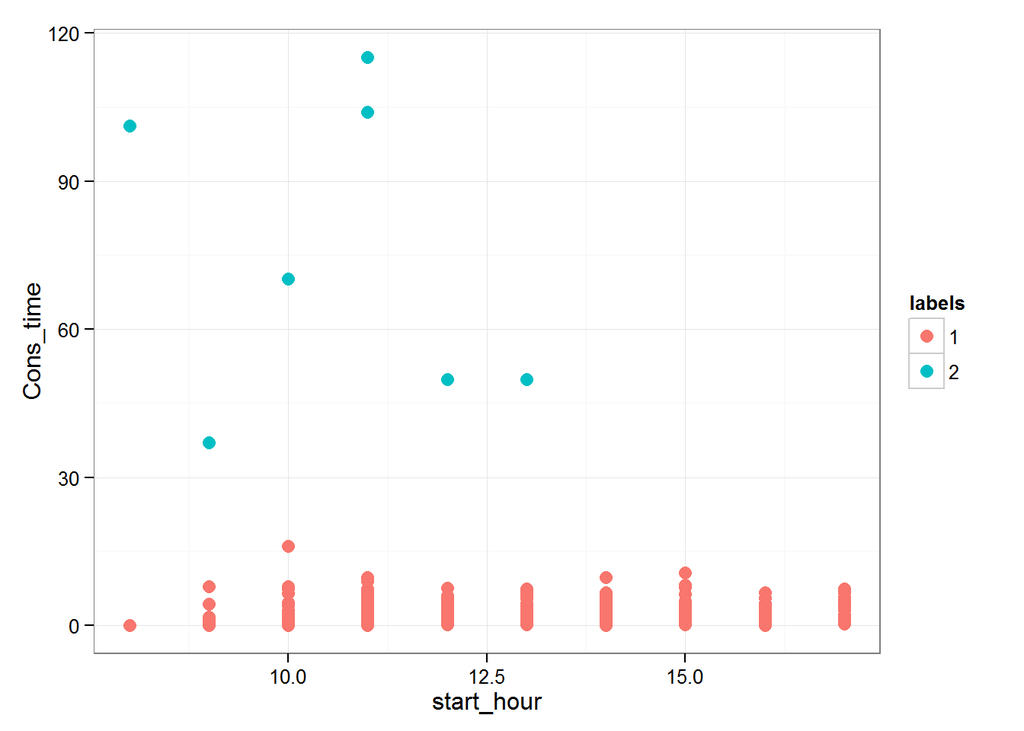

```r
# start hour - the time of consuming
hc <- agnes(start_hour__cons_time, method="ward")
finalData$labels = factor(cutree(hc, k=2))
ggplot(finalData, aes(start_hour, Cons_time)) +
  geom_point(aes(color=labels), size=3) +
  theme_bw()
```

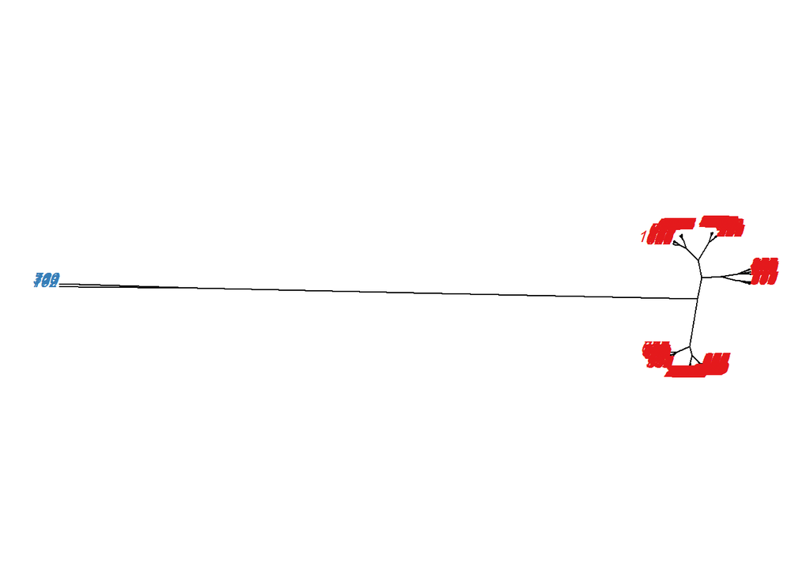

```r
hc <- as.phylo(as.hclust(agnes(start_hour__cons_time, method="ward")))
par(mar=c(1,1,2,1), xpd=NA)
plot(as.phylo(hc), type = "unrooted", cex = 0.8,
     tip.color = cols[finalData$labels])
```

```r
rm(start_hour__cons_time)
```

Visitors are grouped by the hour they started using stations and the time of consuming they started using stations. It can be seen that we can segment visitors in two different clusters according to those two features. First cluster is much more bigger than the second one. There are less visitors who tend to consume stations very long at given hour.

Sizes: First cluster - 99.3 % Second cluster - 0.7 %

First cluster is concentrated around 0 seconds. Second is concentrated around 60 seconds of consumed time. For less then 1% people from the first cluster the time of consuming will be equal to 0, for 99.3 % people the time of consuming will be greater then 0, for 48.24 % people the time of consuming will be greater then 1, for 19.34 % people the time of consuming will be greater then 2, for 12.69 % people the time of consuming will be greater then 3 and for 8.26 % people the time of consuming will be greater then 4. The second cluster represents outliers and they have very large time of consuming and there are only few of them.

### Start Hour - Station

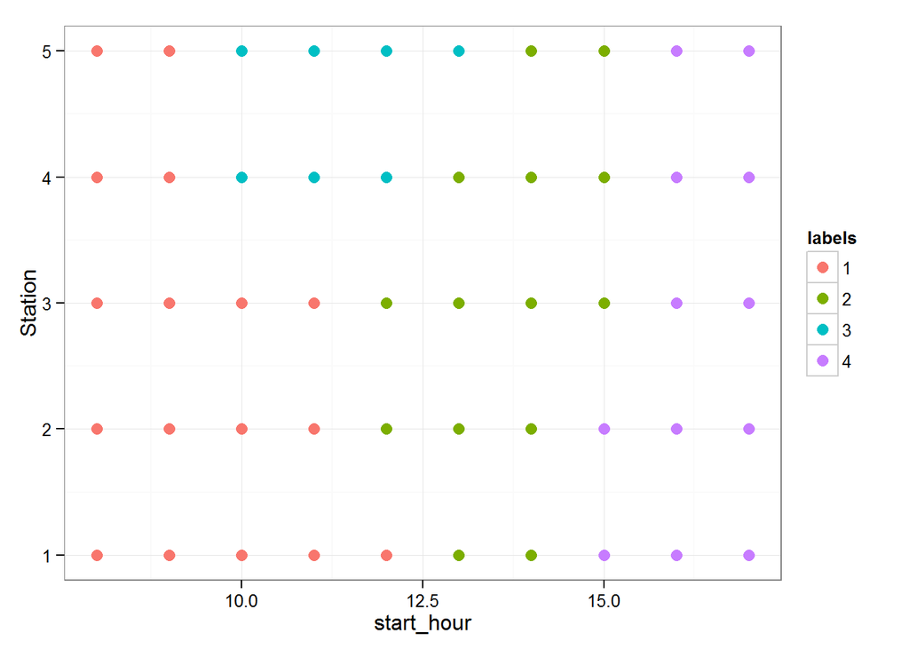

```r
hc <- agnes(start_hour__station, method="ward")
finalData$labels = factor(cutree(hc, k=4))
ggplot(finalData, aes(start_hour, Station)) +
  geom_point(aes(color=labels), size=3) +
  theme_bw()
```

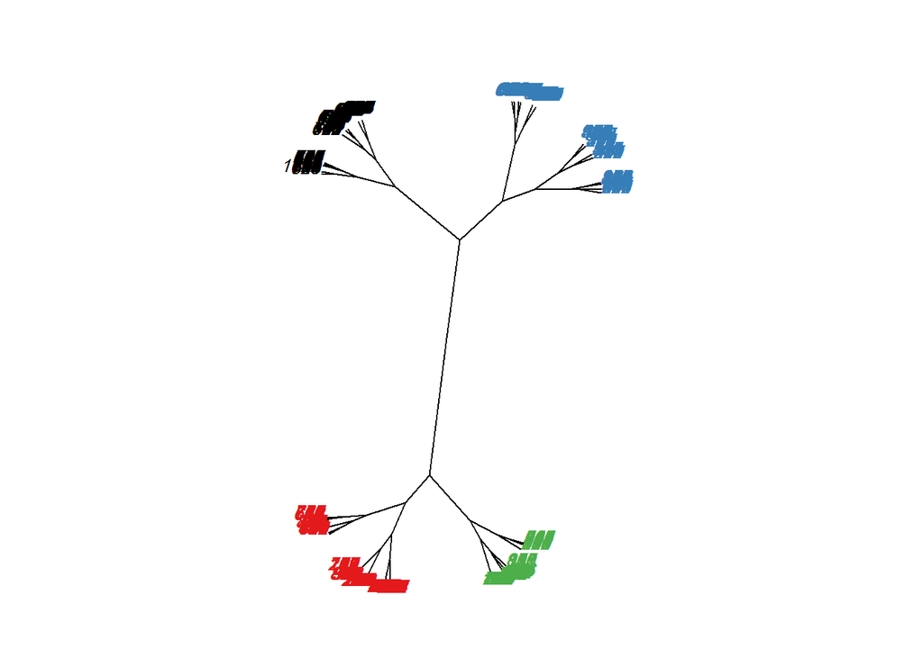

```r
hc <- as.phylo(as.hclust(agnes(start_hour__station, method="ward")))
par(mar=c(1,1,2,1), xpd=NA)
plot(as.phylo(hc), type = "unrooted", cex = 0.8,
     tip.color = cols[finalData$labels])
```

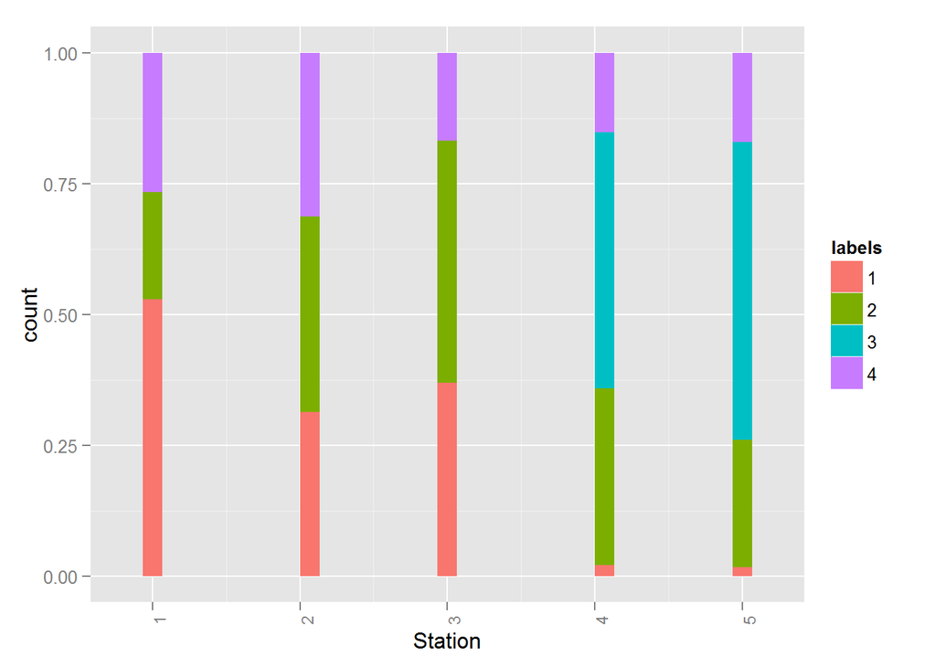

```r
ggplot(data=finalData,aes(x=Station, fill=labels))+
  geom_bar(position = "fill")+theme(axis.text.x=element_text(angle=90,size=9))
```

```r
rm(start_hour__station)
```

Visitors are grouped by the hour they started using stations and the stations they use. It can be seen that we can segment visitors in four different clusters according to those two features. Visitors tend to use different machines in four different time periods.

Sizes: First cluster - 27.3 % Second cluster - 31.9 % Third cluster - 18.6 % Fourth cluster - 22.2 %

50.92 % people from the first cluster will use station 1, 24.91 % will use station 2, 21.61 % will use station 3, 1.83 % will use station 4, 0.73 % will use station 5. 16.93 % people from the second cluster will use station 1, 25.39 % will use station 2, 23.2 % will use station 3, 25.08 % will use station 4, 9.40 % will use station 5. 62.37 % will use station 4, 37.63 % will use station 5. 31.53 % people from the fourth cluster will use station 1, 30.63 % will use station 2, 12.16 % will use station 3, 16.22 % will use station 4, 9.46 % will use station 5.

### Weekday - Time of Consuming

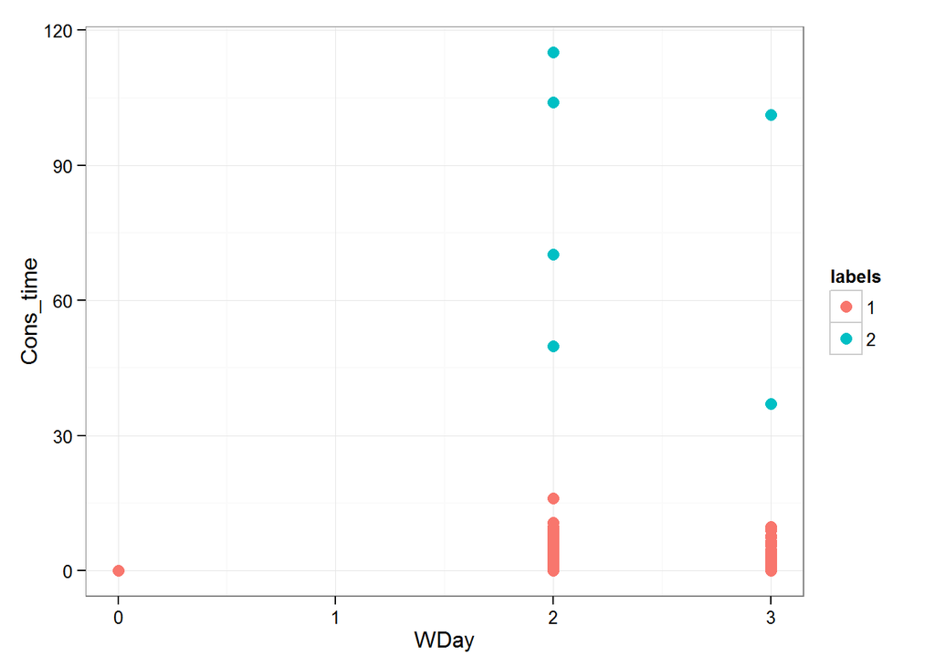

```r
hc <- agnes(wday__cons_time, method="ward")
finalData$labels = factor(cutree(hc, k=2))
ggplot(finalData, aes(WDay, Cons_time)) +
  geom_point(aes(color=labels), size=3) +
  theme_bw()
```

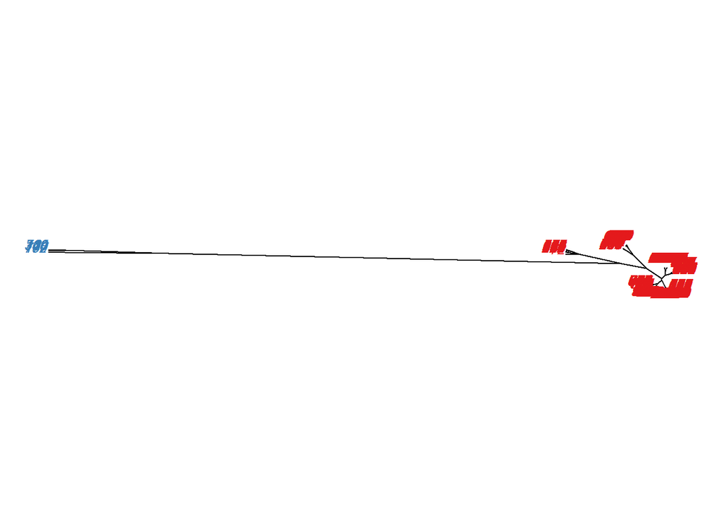

```r
hc <- as.phylo(as.hclust(agnes(wday__cons_time, method="ward")))
par(mar=c(1,1,2,1), xpd=NA)
plot(as.phylo(hc), type = "unrooted", cex = 0.8,
     tip.color = cols[finalData$labels])
```

```r
rm(wday__cons_time)
```

Visitors are grouped by the weekday they started using stations and the time of consuming. It can be seen that we can segment visitors in two different clusters according to those two features. Consuming time is very similar for each weekday and those visitors are in the first, larger cluster and in second, smaller cluster are outliers.

Sizes: First cluster - 99.3 % Second cluster - 0.7 %

First cluster is concentrated around 0 seconds. Second is concentrated around 60 seconds of consumed time. For less then 1% people from the first cluster the time of consuming will be equal to 0, for 99.3 % people the time of consuming will be greater then 0, for 48.24 % people the time of consuming will be greater then 1, for 19.34 % people the time of consuming will be greater then 2, for 12.69 % people the time of consuming will be greater then 3 and for 8.26 % people the time of consuming will be greater then 4. The second cluster represents outliers and they have very large time of consuming and there are only few of them.

### Weekday - Station

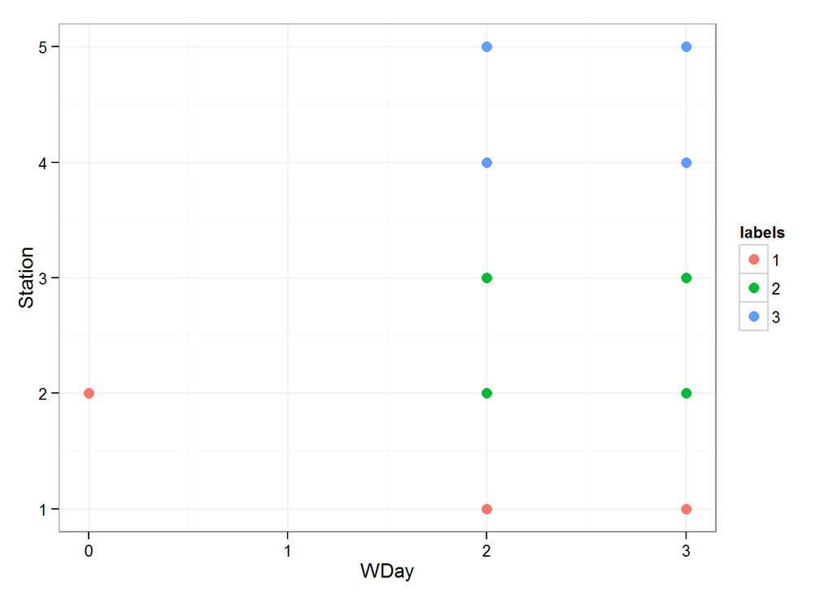

```r
# weekday - station
hc <- agnes(wday__station, method="ward")
finalData$labels = factor(cutree(hc, k=3))
ggplot(finalData, aes(WDay, Station)) +
  geom_point(aes(color=labels), size=3) +
  theme_bw()
```

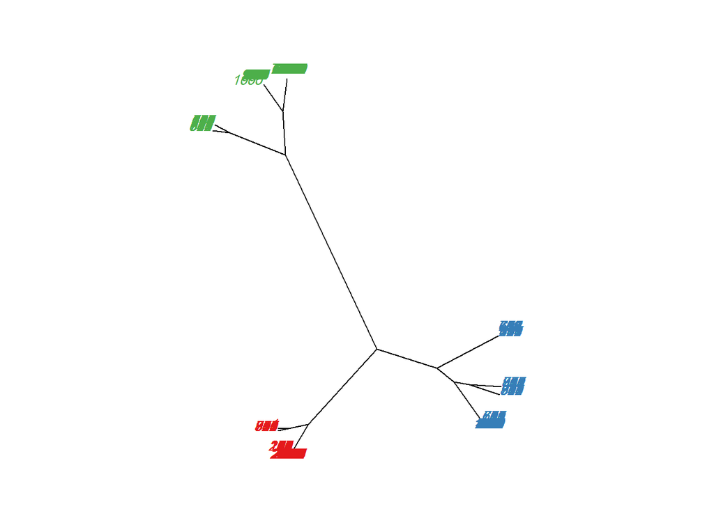

```r
hc <- as.phylo(as.hclust(agnes(wday__station, method="ward")))
par(mar=c(1,1,2,1), xpd=NA)
plot(as.phylo(hc), type = "unrooted", cex = 0.8,
     tip.color = cols[finalData$labels])
```

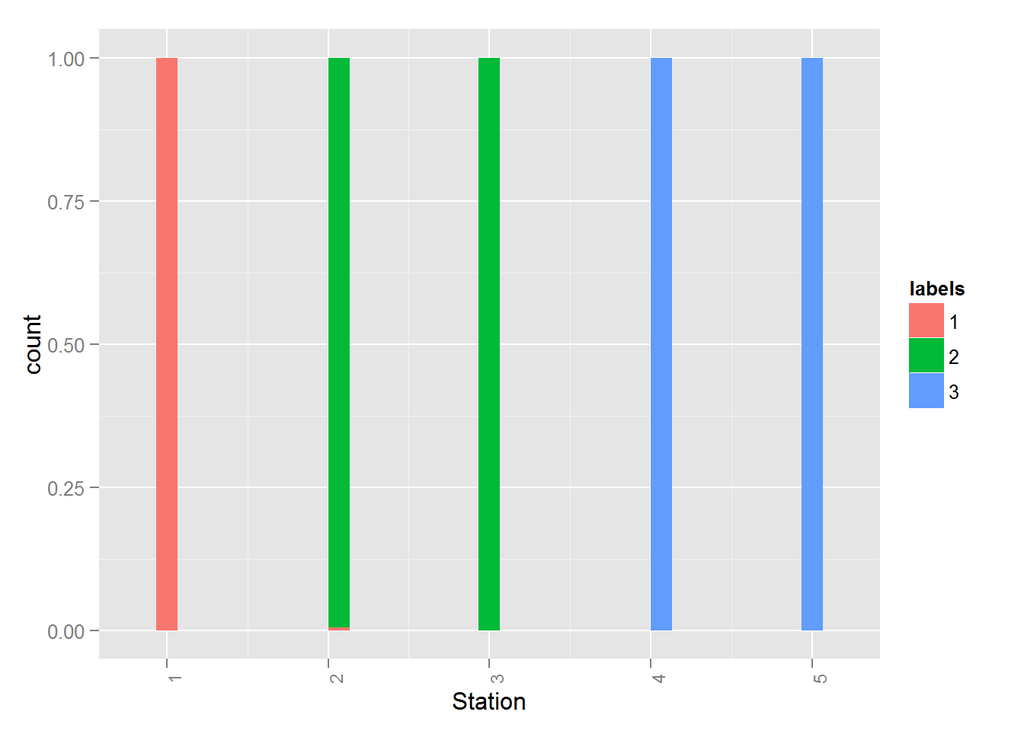

```r
ggplot(data=finalData,aes(x=Station, fill=labels))+
  geom_bar(position = "fill")+theme(axis.text.x=element_text(angle=90,size=9))
```

```r
rm(wday__station)
```

Visitors are grouped by the weekday they started using stations and the station. It can be seen that we can segment visitors in three different clusters according to those two features. Each of the stations have almost equal number of visitors each weekday.

Sizes: First cluster - 26.4 % Second cluster - 37.6 % Third cluster - 36 %

### Time of Consuming - Station

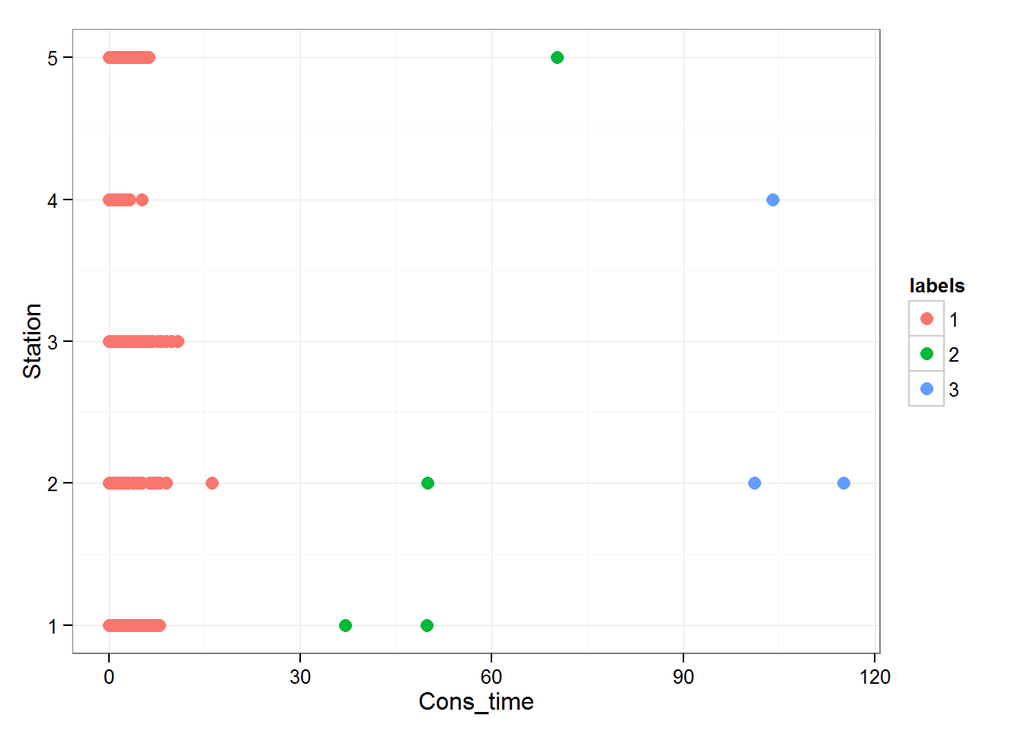

```r
# time of consuming - station
hc <- agnes(cons_time__station, method="ward")
finalData$labels = factor(cutree(hc, k=3))
ggplot(finalData, aes(Cons_time, Station)) +
  geom_point(aes(color=labels), size=3) +
  theme_bw()
```

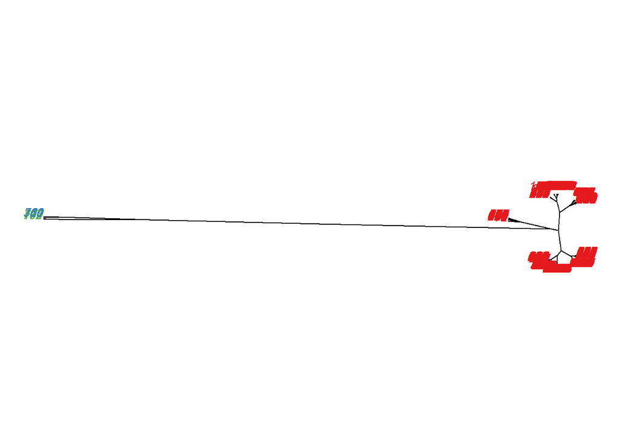

```r
hc <- as.phylo(as.hclust(agnes(cons_time__station, method="ward")))
par(mar=c(1,1,2,1), xpd=NA)
plot(as.phylo(hc), type = "unrooted", cex = 0.8,
     tip.color = cols[finalData$labels])
```

```r
rm(cons_time__station)
```

Visitors are grouped by the time of consuming and the station. It can be seen that we can segment visitors in three different clusters according to those two features. The largest cluster is cluster with visitors that use stations less than cca. 20 seconds and two smaller clusters are clusters with visitors that use stations between 20 and 90 seconds and more than 90 seconds.

Sizes: First cluster - 99.3 % Second cluster - 0.4 % Third cluster - 0.3 %

### All Features

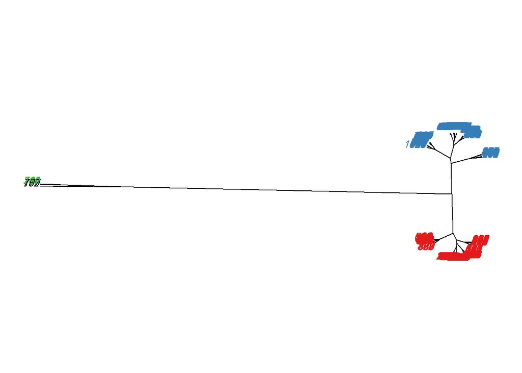

```r
# all features
hc <- agnes(all, method="ward")
finalData$labels = factor(cutree(hc, k=4))

hc <- as.phylo(as.hclust(agnes(all, method="ward")))
par(mar=c(1,1,2,1), xpd=NA)
plot(as.phylo(hc), type = "unrooted", cex = 0.8,
     tip.color = cols[finalData$labels])
```

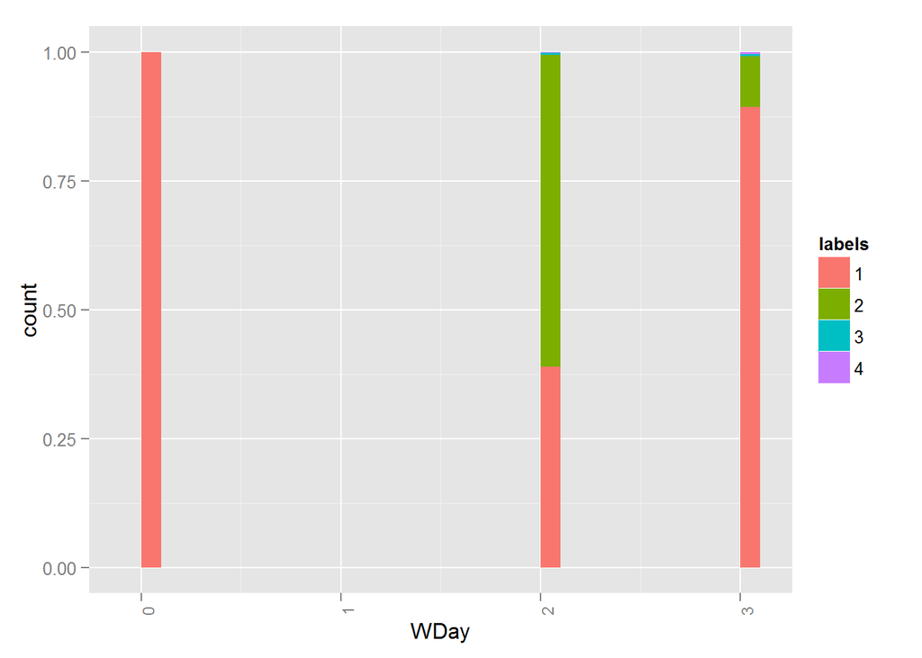

```r
ggplot(data=finalData,aes(x=WDay, fill=labels))+
  geom_bar(position = "fill")+theme(axis.text.x=element_text(angle=90,size=9))
```

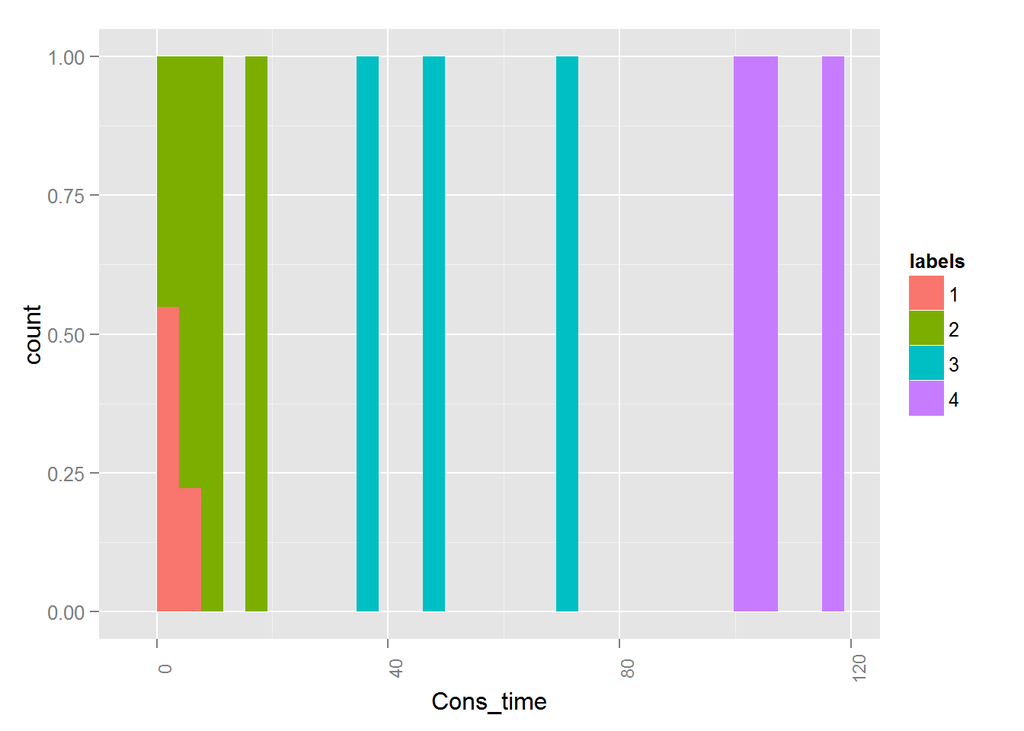

```r
ggplot(data=finalData,aes(x=Cons_time, fill=labels))+
  geom_bar(position = "fill")+theme(axis.text.x=element_text(angle=90,size=9))
```

```r
rm(all)
```

Visitors are grouped using all features. It can be seen that if we consider all features, we can group visitors in four different groups, there are four main types of visitors, but also it is possible to divide them even into smaller clusters, as it can be seen from the graph.

Sizes: First cluster - 51.2 % Second cluster - 48.1 % Third cluster - 0.4 % Fourth cluster - 0.3 %

For the first cluster, mean of start hour is 11.17, minimum start hour is 8, maximum start hour is 13, mean of end hour is 11.2, the most used station is station 4 and less used is station 5 and mean of the time of consuming is 1.14. For the second cluster, mean of start hour is 14.71, minimum start hour is 10, maximum start hour is 17, mean of end hour is 14.75, the most used station is station 1 and less used is station 5 and mean of the time of consuming is 1.86. So people from first cluster like to go to museum at around 11:00, they like station 4 and they spend 1.14 seconds on stations. People from second cluster like to go to museum at around 15:00, they like station 1 and they spend 1.86 seconds on stations. The third and fourth cluster represent outliers.

# Conclusion

How to define the similarity measure between visitors? As above, we calculated similarity between visitors using different models:

- start_hour, end_hour, weekday, consumed_time and station features with Hierarchical clustering.
- Start Time and Consumed Time with k-means
- visited pages with k-means

Is the population homogenous or heterogonous. If heterogeneous then how many groups you can derive/define? Population is heterogeneous as it can be seen from the last graph where we used all features. Four main clusters can be derived, but also we can divide those four classter into smaller ones.

How to characterize different groups of visitors? In different groups of visitors, visitors started using stations on different weekdays, time of consumption is different, hours when they started using station are different, machines they are using are different and so on.

And For K-means with normalized dataset We noticed that:

- one of them contain the long period visits  
- second one for the morning time befor 12  
- third one for Afternoon time from 12 to 15  
- fouth one for after evening after 15

And the visted pages table describe the clusters when we used the interactions dataset.

Is there a pattern in stations that visitor tends to visit? We analyzed only few stations because of computational speed and visitors tend to visit those stations equally. And we have some plots with description to show some statistical information about the data.